# Représenter des données

L3 économie-finance

Elias Bouacida

12 octobre 2026

# Reprise de la séance 3

## Le code tourne, le résultat est faux

Ce script s’exécute **sans erreur et sans avertissement**. Pourtant le commentaire qui l’accompagne est faux.

```r
# On écarte les personnes qui déclarent plus de 10h de télévision par jour,
# puis on calcule la moyenne sur l'ensemble des enquêtés.
d |> mutate(heures.tv = if_else(heures.tv > 10, NA_real_, heures.tv))

d |> summarise(
  effectif = n(),
  tv_moyenne_tous = mean(heures.tv, na.rm = TRUE)
)
```

Trouvez ce qui ne va pas, corrigez, et expliquez en français ce qui s’est passé.

## Correction

```r
d_corrige <- d |> mutate(heures.tv = if_else(heures.tv > 10, NA_real_, heures.tv))

d_corrige |> summarise(
  effectif = sum(!is.na(heures.tv)),
  tv_moyenne = mean(heures.tv, na.rm = TRUE)
)
```

```
# A tibble: 1 × 2
  effectif tv_moyenne
     <int>      <dbl>
1     1991       2.23
```

**Important**

Deux erreurs superposées : le `mutate()` sans `<-` ne modifiait rien, donc le recodage annoncé n’avait jamais lieu ; et l’effectif affiché (`n()`) comptait tout le tableau au lieu des seuls répondants, cachant le `na.rm = TRUE`.

# Pourquoi un graphique

## Ce qu’un tableau ne dit pas

La séance dernière, nous avons résumé l’âge des enquêtés :

```r
d |> summarise(
  moyenne = mean(age),
  ecart_type = sd(age),
  mediane = median(age)
)
```

```
# A tibble: 1 × 3
  moyenne ecart_type mediane
    <dbl>      <dbl>   <dbl>
1    48.2       16.9      48
```

Trois nombres. Mais **quelle est la forme** de cette distribution ? Y a-t-il un seul groupe d’âge, ou plusieurs ? Des valeurs aberrantes ?

## La même variable, en image

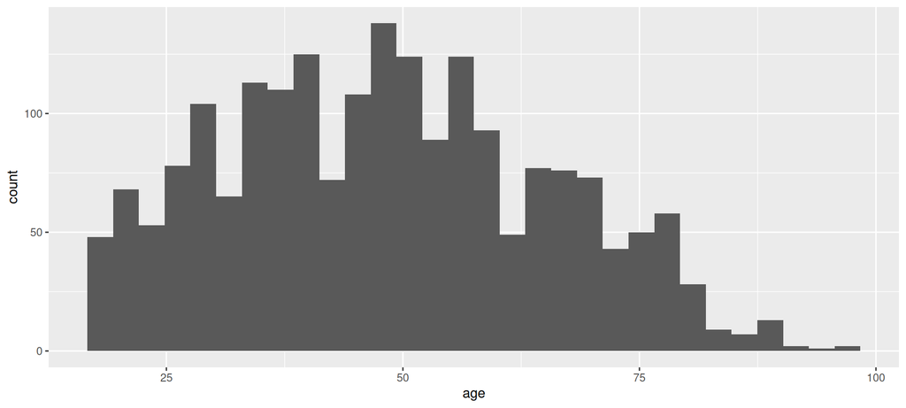

Deux indicateurs identiques peuvent correspondre à des distributions très différentes. C’est ce que nous allons apprendre à voir.

## `ggplot2`

`ggplot2` permet de construire des graphiques avec une syntaxe cohérente et puissante. Elle demande l’apprentissage d’un petit langage supplémentaire, mais permet ensuite de construire des graphiques complexes efficacement.

Une de ses particularités : les données d’un graphique sont **toujours** dans un tableau de données.

```r
library(tidyverse)   # ggplot2 est inclus
library(questionr)
data(hdv2003)
d <- as_tibble(hdv2003)
```

Ce chapitre est élaboré à partir du chapitre 8 de Barnier et Kauffmann (2023).

# Les trois ingrédients

## Initialisation : quelles données ?

Un graphique s’initialise avec la fonction `ggplot()`. On lui passe le tableau de données.

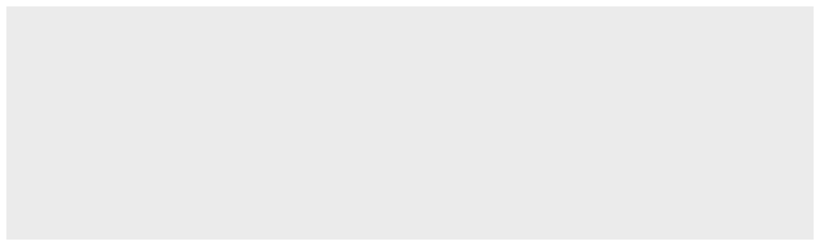

```r
ggplot(d)
```

Rien ne s’affiche : nous n’avons pas encore dit **quoi** représenter, ni **comment**.

## Géométrie : comment ?

Il faut ajouter un élément de représentation graphique, appelé **géométrie** (`geom`). On l’ajoute avec l’opérateur `+`.

```r
ggplot(d) + geom_histogram()
```

Cela ne fonctionne pas encore : il manque la variable à représenter.

## Esthétique : quelle variable ?

On indique la variable à représenter avec la fonction `aes()`. Ici, le paramètre `x` désigne la variable portée par l’axe horizontal.

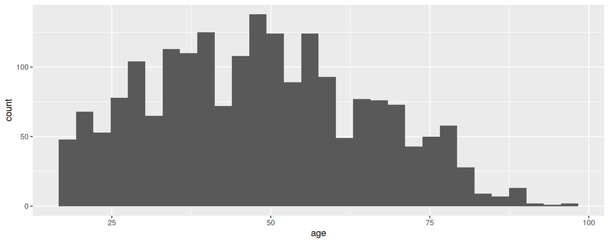

```r
ggplot(d) + geom_histogram(aes(x = age))
```

## Changer de variable

Il suffit de changer la valeur de `x` :

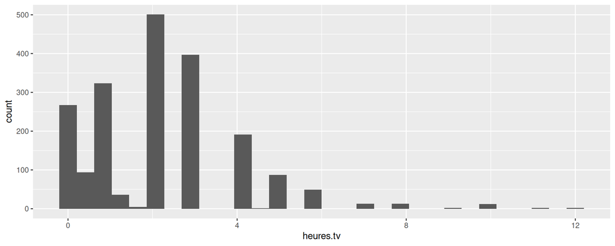

```r
ggplot(d) + geom_histogram(aes(x = heures.tv))
```

**Note**

R affiche un avertissement signalant les valeurs manquantes écartées. Un **avertissement** n’est pas une erreur : le graphique est produit. Mais lisez-le – il vous dit combien d’observations ne sont pas représentées.

## En résumé

Pour faire un graphique, il faut trois choses :

1. **Des données** : l’argument de `ggplot()`
2. **Un type de représentation** : `geom_xxxx`
3. **Une ou des variables** : l’argument `aes()`

On lie les éléments avec l’opérateur `+`.

# Représenter une variable

## Une variable quantitative : l’histogramme

L’histogramme découpe la variable en intervalles et compte les observations dans chacun. On contrôle le découpage avec `bins` :

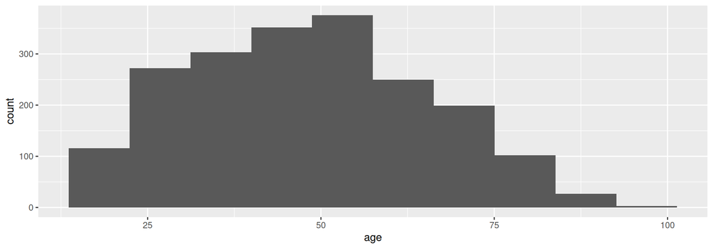

```r
ggplot(d) +
  geom_histogram(aes(x = age), bins = 10)
```

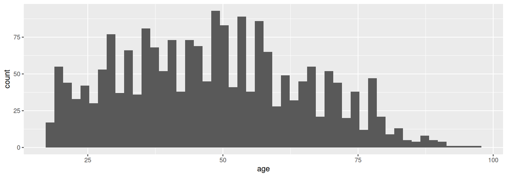

```r
ggplot(d) +
  geom_histogram(aes(x = age), bins = 50)
```

**Avertissement**

Le nombre d’intervalles change ce que vous voyez. Identifiez l’intervalle qui correspond à ce que vous étudiez, ou essayez-en toujours plusieurs avant de conclure quoi que ce soit sur la forme d’une distribution.

## Une variable qualitative : le diagramme en barres

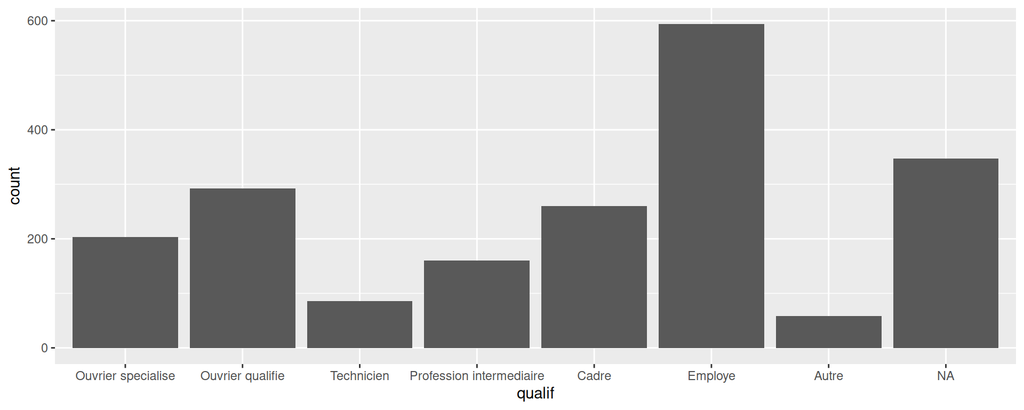

```r
ggplot(d) + geom_bar(aes(x = qualif))
```

**Astuce**

`geom_bar()` compte lui-même les effectifs : c’est l’équivalent graphique du `count()` de la séance dernière. Les valeurs manquantes apparaissent comme une barre.

## Étiquettes illisibles

Quand les modalités sont longues, on inverse les axes en passant la variable en `y` :

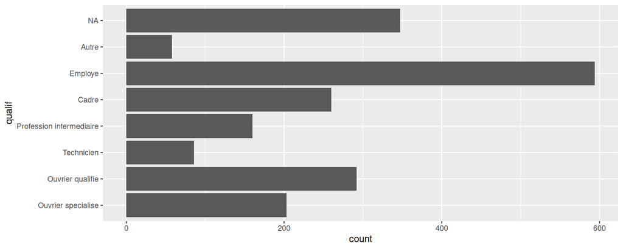

```r
ggplot(d) + geom_bar(aes(y = qualif))
```

## Exercice

1. Représentez la distribution du nombre de frères et sœurs (`freres.soeurs`).
2. Faites un diagramme en barres de la variable `relig`. Comparez avec le `count()` de la séance dernière.
3. Représentez la distribution de l’âge avec 5, puis 20, puis 100 intervalles. Que voyez-vous apparaître, et que voyez-vous disparaître ?

# Croiser deux variables

## Nuage de points

Pour deux variables quantitatives, on utilise `geom_point()`, qui demande une position en `x` et une en `y` :

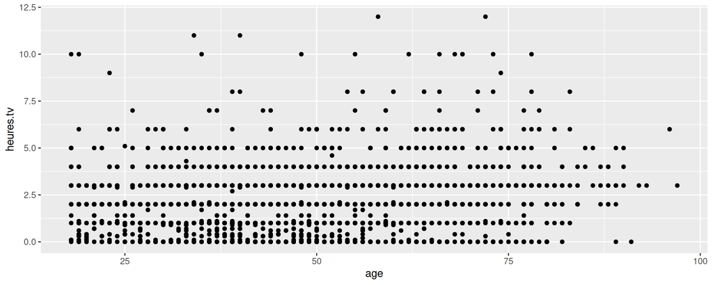

```r
ggplot(d) + geom_point(aes(x = age, y = heures.tv))
```

## Le problème des points superposés

Il y a 2000 observations et beaucoup se superposent exactement : impossible de savoir où se concentrent les enquêtés.

La transparence (`alpha`) et un léger décalage aléatoire (`geom_jitter`) rendent la densité visible :

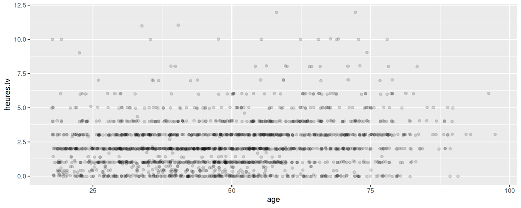

```r
ggplot(d) + geom_jitter(aes(x = age, y = heures.tv), alpha = 0.15)
```

**Important**

Le premier graphique n’était pas faux, il était illisible. Un graphique peut cacher l’information aussi bien qu’un tableau.

## Quantitative selon qualitative : la boîte à moustaches

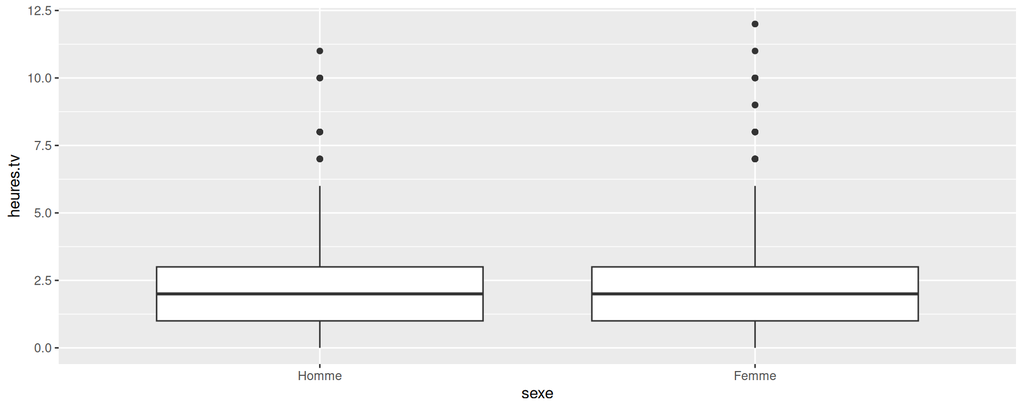

```r
ggplot(d) + geom_boxplot(aes(x = sexe, y = heures.tv))
```

## Lire une boîte à moustaches

- Le trait épais au milieu est la **médiane**.
- La boîte va du **premier au troisième quartile** : elle contient la moitié centrale des observations.
- Les moustaches s’étendent jusqu’aux valeurs extrêmes, dans la limite d’une fois et demie la hauteur de la boîte.
- Les points au-delà sont affichés individuellement : ce sont les valeurs **atypiques**.

Ce sont exactement les quartiles calculés la séance dernière avec `quantile()`. La boîte est leur traduction visuelle.

## Comparer plusieurs groupes

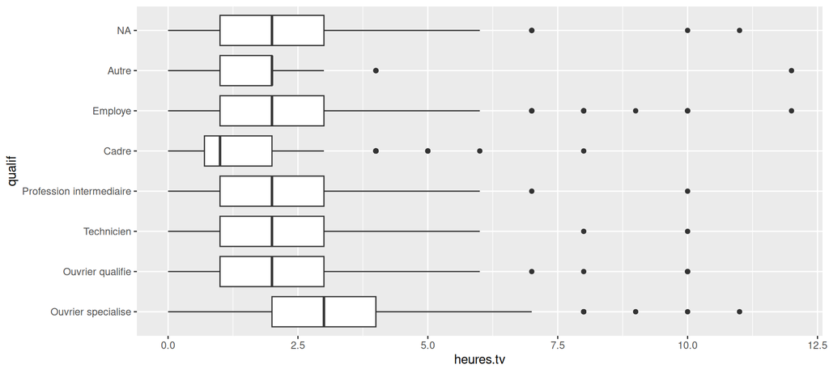

```r
ggplot(d) + geom_boxplot(aes(x = heures.tv, y = qualif))
```

**Astuce**

Comparez avec le tableau `group_by(qualif) |> summarise(...)` de la séance dernière : même information, mais la dispersion de chaque groupe devient visible.

# Mappages

## Relier un attribut à une variable

Un **mappage** est une mise en relation entre un attribut graphique (position, couleur, taille, transparence) et une variable du tableau.

Tous les mappages se déclarent dans `aes()`.

## Couleur

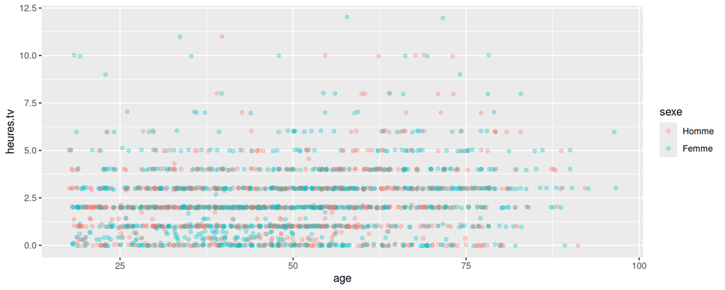

```r
ggplot(d) +
  geom_jitter(aes(x = age, y = heures.tv, color = sexe), alpha = 0.3)
```

## Taille et transparence

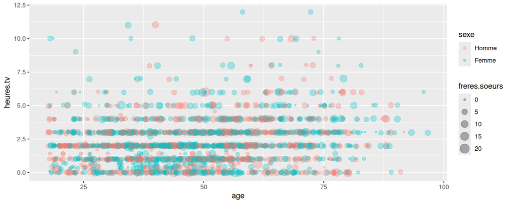

```r
ggplot(d) +
  geom_jitter(
    aes(x = age, y = heures.tv, color = sexe, size = freres.soeurs),
    alpha = 0.3
  )
```

Chaque `geom` possède sa propre liste de mappages possibles.

## `aes()` ou pas `aes()` ?

Parfois on veut fixer un attribut sans le relier à une variable : tous les points en rouge, par exemple. On utilise le même argument `color`, mais **à l’extérieur** de `aes()`.

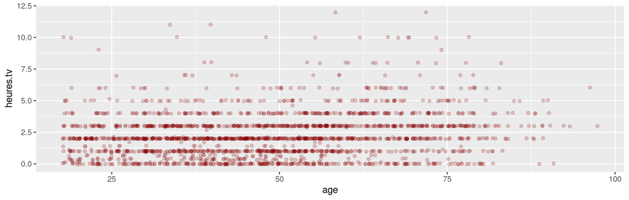

```r
ggplot(d) +
  geom_jitter(
    aes(x = age, y = heures.tv),
    color = "darkred", alpha = 0.2
  )
```

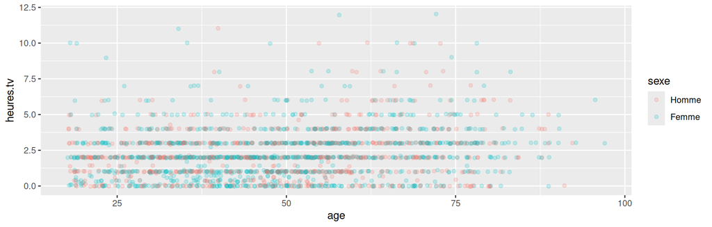

```r
ggplot(d) +
  geom_jitter(
    aes(x = age, y = heures.tv,
        color = sexe),
    alpha = 0.2
  )
```

## La règle

**Important**

Si l’attribut **dépend d’une variable**, il va **dans** `aes()`.

Si l’attribut est **le même pour tous les points**, il va **en dehors** de `aes()`.

On peut mélanger les deux. Ici la taille dépend d’une variable, la couleur est constante :

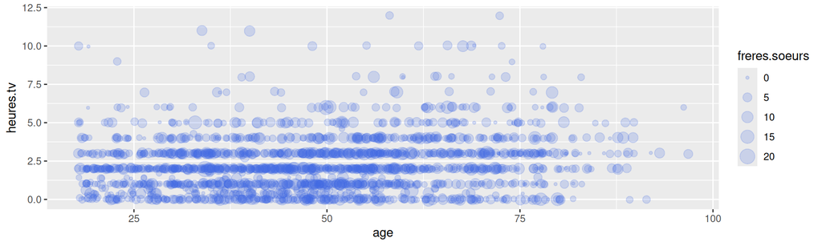

```r
ggplot(d) +
  geom_jitter(aes(x = age, y = heures.tv, size = freres.soeurs), color = "royalblue", alpha = 0.2)
```

## Une erreur classique

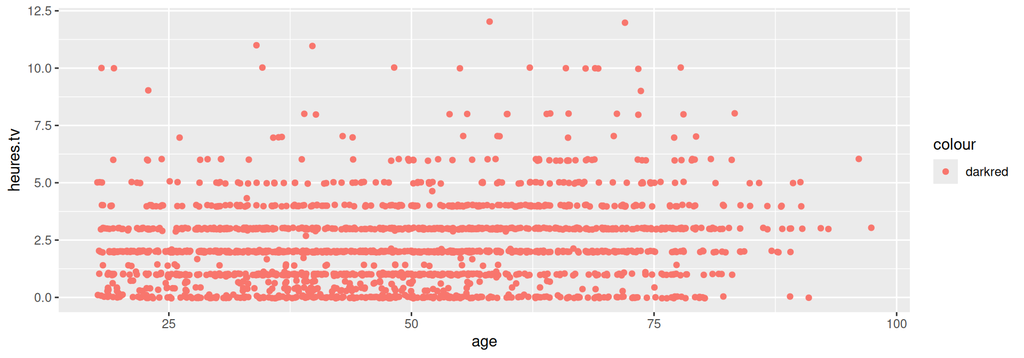

```r
ggplot(d) + geom_jitter(aes(x = age, y = heures.tv, color = "darkred"))
```

`color` est ici **dans** `aes()` : R comprend qu’il faut colorer selon une variable qui vaudrait « darkred » pour tout le monde. Il crée donc un groupe unique, lui attribue sa première couleur de palette, et ajoute une légende absurde. Aucun message d’erreur.

# Superposer et découper

## Plusieurs géométries

On peut ajouter plusieurs `geom` avec `+`. Pour éviter de répéter les mappages, on les déclare dans `ggplot()` : ils sont hérités par toutes les géométries.

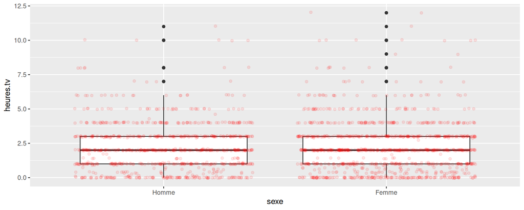

```r
ggplot(d, aes(x = sexe, y = heures.tv)) +
  geom_boxplot() +
  geom_jitter(color = "red", alpha = 0.1)
```

## Ajouter une tendance

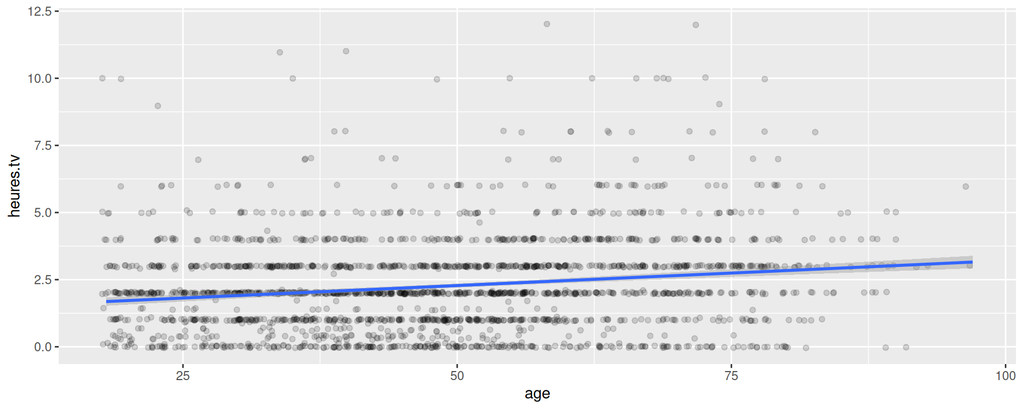

```r
ggplot(d, aes(x = age, y = heures.tv)) +
  geom_jitter(alpha = 0.15) +
  geom_smooth(method = "lm")
```

**Note**

`geom_smooth(method = "lm")` ajoute une droite de régression linéaire. Vous la retrouverez en économétrie ; ici, elle sert seulement à visualiser une tendance.

## Découper en sous-graphiques

`facet_wrap()` répète le même graphique pour chaque modalité d’une variable :

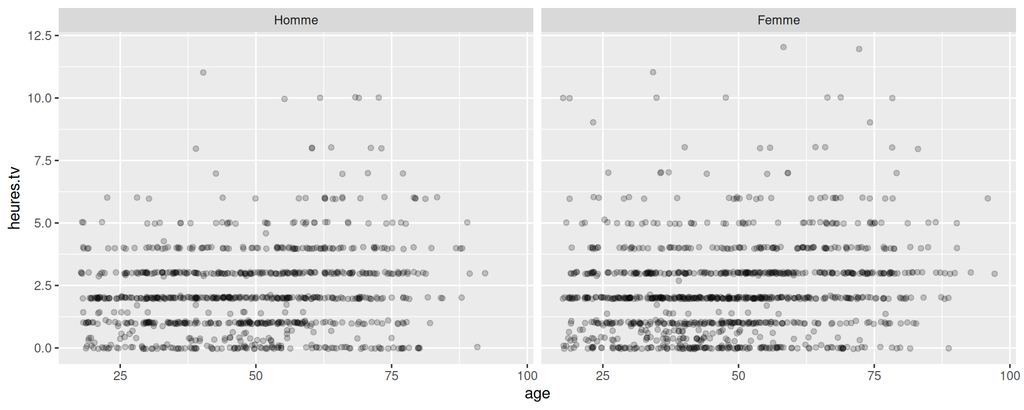

```r
ggplot(d, aes(x = age, y = heures.tv)) +
  geom_jitter(alpha = 0.2) +
  facet_wrap(~ sexe)
```

C’est le pendant graphique du `group_by()` de la séance dernière.

Quand une commande devient longue, répartissez-la sur plusieurs lignes en plaçant le `+` **en fin de ligne**, pour que R comprenne que la commande continue.

# Mise en forme

## Les échelles

Les *scales* modifient la manière dont un attribut est relié aux valeurs d’une variable, et l’affichage de la légende correspondante. Elles s’ajoutent avec `+` et prennent la forme `scale_<attribut>_<type>`.

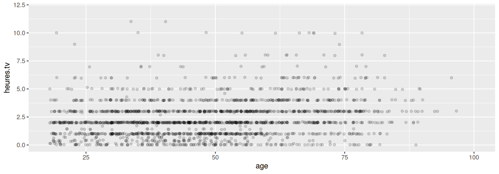

```r
ggplot(d) +
  geom_jitter(aes(x = age, y = heures.tv), alpha = 0.15) +
  scale_x_continuous(limits = c(18, 100)) +
  scale_y_continuous(limits = c(0, 12))
```

## Titres et étiquettes

`labs()` règle tous les textes du graphique en une seule fois :

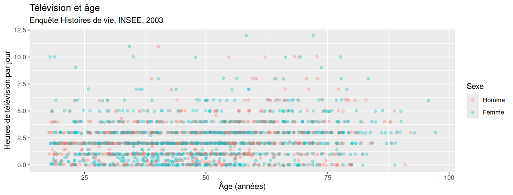

```r
ggplot(d) +
  geom_jitter(aes(x = age, y = heures.tv, color = sexe), alpha = 0.3) +
  labs(
    title = "Télévision et âge",
    subtitle = "Enquête Histoires de vie, INSEE, 2003",
    x = "Âge (années)",
    y = "Heures de télévision par jour",
    color = "Sexe"
  )
```

## Thèmes

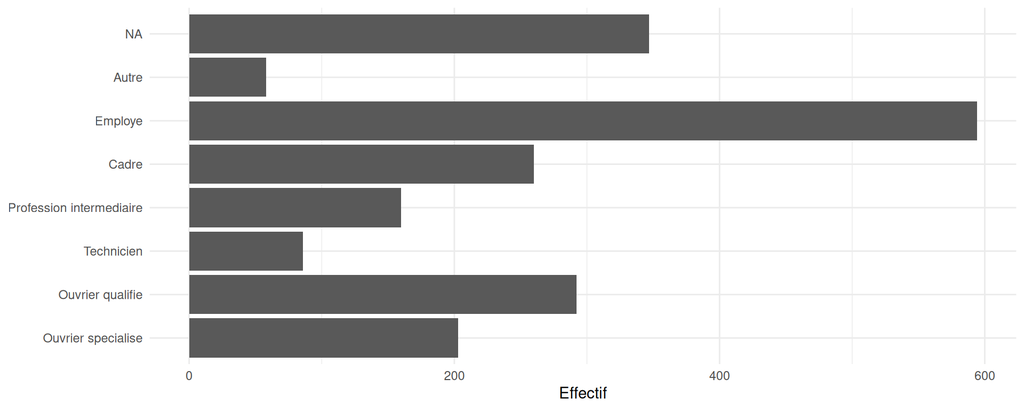

```r
ggplot(d) +
  geom_bar(aes(y = qualif)) +
  labs(x = "Effectif", y = NULL) +
  theme_minimal()
```

Essayez aussi `theme_bw()`, `theme_classic()`, `theme_light()`.

## Un graphique lisible

- **Des axes nommés**, en français, avec l’unité. `heures.tv` n’est pas un titre d’axe.
- **La source**, en sous-titre ou en légende.
- **Pas de décoration inutile.** Les couleurs doivent porter de l’information, sinon elles distraient.
- **Le nombre d’observations** représentées, surtout si des valeurs manquantes ont été écartées.

## Enregistrer un graphique

```r
ggsave("tv_age.png", width = 8, height = 5)
```

`ggsave()` enregistre le dernier graphique affiché, dans le dossier de travail. Le format est déduit de l’extension du fichier.

# À vous

## Exercices

Dans un script commenté :

1. Représentez la distribution de l’âge selon le sexe, avec des boîtes à moustaches.
2. Faites un diagramme en barres du niveau d’études (`nivetud`), lisible.
3. Le nombre d’heures de télévision diffère-t-il selon que l’on pratique un sport ? Représentez-le, puis comparez avec le tableau correspondant de la séance dernière.
4. Reprenez le nuage de points âge / heures de télévision, découpez-le par catégorie socio-professionnelle avec `facet_wrap()`, et donnez-lui un titre et des axes nommés.

**Astuce**

Pour chaque graphique, écrivez en commentaire ce que vous y lisez. Un graphique sans lecture ne sert à rien.

## Exercice swirl

```r
library(swirl)
swirl()
```

Faites la leçon **Representations_graphiques**.

**Note**

En option, pour pratiquer davantage : la leçon facultative **Exercice_5** reprend nuage de points, boîte à moustaches et diagramme en bâtons. Voir [`LECONS_OPTIONNELLES.md`](https://github.com/EliasBcd/InitiationR/blob/main/LECONS_OPTIONNELLES.md).

## Pour la prochaine séance

La séance 5 est un projet : une analyse complète, de votre choix, sur `hdv2003`.

- Choisissez **deux ou trois questions** auxquelles vous voulez répondre.
- Écrivez-les avant de coder.
- Apportez-les à la séance prochaine.

## Ressources

L’[antisèche ggplot2](https://posit.co/resources/cheatsheets/) résume l’essentiel en deux pages. Elle est aussi accessible depuis RStudio : *Help > Cheatsheets > Data visualization with ggplot2*.

La [documentation officielle](https://ggplot2.tidyverse.org/reference/) donne la liste complète des géométries, avec un exemple pour chacune.

Le chapitre [Data visualisation](https://r4ds.hadley.nz/data-visualize) de *R for Data Science* est une bonne introduction complémentaire, en anglais.

Barnier, Julien, et Mayeul Kauffmann. 2023. *"Introduction à R et au tydiverse"*. Version v2023-05-02. Zenodo, released. https://doi.org/10.5281/zenodo.6382598.